# MathScoresRegression

```r
knitr::opts_chunk$set(echo = TRUE)
library(tidyverse)
options(scipen = 999)
```

## Does Poverty Predict Math Scores? Testing a School Board Member’s Claim

### Introduction

A school board member in Montgomery County, Pennsylvania has claimed at a public meeting that elementary schools with fewer students on free and reduced-price meals do better on standardized math tests. That’s a testable claim, and as data journalists, our job is to test it.

We have school-level data from Montgomery County, Pa. that includes each school’s FARMS percentage (the share of students eligible for Free and Reduced-price Meal System) and the percentage of students who met or exceeded math expectations on state tests. We’ll use linear regression to evaluate whether the school board member’s claim holds up, and we’ll learn something important about what happens when you trust a model before examining your data.

### Loading the Data

```r
schools <- read_csv("https://raw.githubusercontent.com/dwillis/jour405_files/refs/heads/main/montgomery_pa.csv")
```

### Task 1: Examine the Data Before You Plot Anything

Before we visualize anything, let’s look at what we’re working with.

```r
summary(schools$`FARMS Pct`)
```

```
##    Min. 1st Qu.  Median    Mean 3rd Qu.    Max.
##   10.66   18.55   30.45   38.30   45.06  100.00
```

```r
schools |> arrange(desc(`FARMS Pct`)) |> head(10)
```

```
## # A tibble: 10 × 3
##    `School Name`          `FARMS Pct` `% Met or Exceeded Math Expectations`
##    <chr>                        <dbl>                                 <dbl>
##  1 BARTH EL SCH                 100                                    60.3
##  2 BRIDGEPORT EL SCH            100                                    76.6
##  3 FRANKLIN EL SCH              100                                    61.4
##  4 LINCOLN EL SCH               100                                    75
##  5 MARSHALL STREET EL SCH       100                                    77.6
##  6 PAUL V FLY EL SCH            100                                    77.8
##  7 RUPERT EL SCH                100                                    57.6
##  8 WHITEHALL EL SCH             100                                    59.7
##  9 E M CROUTHAMEL EL SCH         53.9                                  49.1
## 10 CHELTENHAM EL SCH             52.9                                  66.4
```

```r
schools |> arrange(`FARMS Pct`) |> head(10)
```

```
## # A tibble: 10 × 3
##    `School Name`                      `FARMS Pct` % Met or Exceeded Math Expec…¹
##    <chr>                                    <dbl>                          <dbl>
##  1 Upper Providence Elementary School        10.7                           59.3
##  2 Maple Glen Elementary                     11.0                           42.4
##  3 FORT WASHINGTON EL SCH                    11.2                           65.7
##  4 WHITEMARSH EL SCH                         11.5                           26.1
##  5 JARRETTOWN EL SCH                         12.7                           53.8
##  6 MERION EL SCH                             13.3                           35.3
##  7 BELMONT HILLS EL SCH                      14.9                           34.2
##  8 Salford Hills El Sch                      15.7                           73.5
##  9 SKIPPACK EL SCH                           16.6                           68.3
## 10 STONY CREEK EL SCH                        16.7                           46.2
## # ℹ abbreviated name: ¹`% Met or Exceeded Math Expectations`
```

Look at the distribution of FARMS percentages. Do any values look unusual or suspicious? What might it mean if a school has a FARMS percentage of exactly 100? Write two or three sentences describing what you see and whether anything concerns you.

I think that having 8/57 schools with 100% of their students qualifying for FARMS seems extremely strange. The only answers I have for that is that it could be an economically deprived area of Montgomery county. My only other idea is that the school board could be implementing the program for everyone to help even the playing field among the kids, but then again the data says that 100% of the kids are QUALIFYING. It’s perplexing but I definitely am really skeptical of these numbers. They could be lying?

### Task 2: Create a Scatterplot and Describe the Results

Now let’s visualize the relationship between FARMS percentage and math scores for all schools.

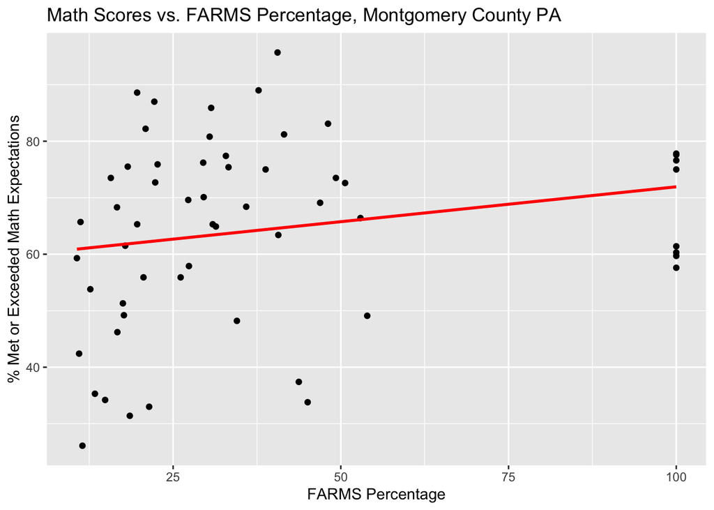

```r
schools |>
  ggplot(aes(x = `FARMS Pct`, y = `% Met or Exceeded Math Expectations`)) +
  geom_point() +
  geom_smooth(method = "lm", se = FALSE, color = "red") +
  labs(x = "FARMS Percentage", y = "% Met or Exceeded Math Expectations",
       title = "Math Scores vs. FARMS Percentage, Montgomery County PA")
```

Describe what you see. Is there a clear trend? Does the regression line look like it represents the data well, or does it seem to be pulled in an odd direction? Connect what you observed in Task 1 to what you see here.

There is no clear trend, the points are spread out and scattered all over the place. Schools with 50% of kids on FARMS did better and worse than the schools on 100%.The line is a suggestion of a median but isnt coherent with the spread of the points.

### Task 3: Run the Regression Model

Let’s build the linear regression model using all schools.

```r
model <- lm(`% Met or Exceeded Math Expectations` ~ `FARMS Pct`, data = schools)
summary(model)
```

```
##
## Call:
## lm(formula = `% Met or Exceeded Math Expectations` ~ `FARMS Pct`,
##     data = schools)
##
## Residuals:
##     Min      1Q  Median      3Q     Max
## -34.897 -11.628   3.295  11.713  31.111
##
## Coefficients:
##             Estimate Std. Error t value            Pr(>|t|)
## (Intercept) 59.57897    3.71055  16.057 <0.0000000000000002 ***
## `FARMS Pct`  0.12349    0.07874   1.568               0.123
## ---
## Signif. codes:  0 '***' 0.001 '**' 0.01 '*' 0.05 '.' 0.1 ' ' 1
##
## Residual standard error: 16.32 on 55 degrees of freedom
## Multiple R-squared:  0.04281,    Adjusted R-squared:  0.0254
## F-statistic:  2.46 on 1 and 55 DF,  p-value: 0.1225
```

There are three things to examine: the p-value, the Adjusted R-squared, and the coefficient for FARMS Pct.

The **p-value** tells you whether the relationship is statistically significant. The **Adjusted R-squared** tells you how much of the variation in math scores is explained by FARMS percentage — it’s already a percentage, so a value of 0.025 means 2.5%, not 25%. The **coefficient** on FARMS Pct tells you the direction and size of the relationship: positive means higher FARMS predicts higher math scores; negative means higher FARMS predicts lower scores.

Report all three values and describe what they tell you. Does this model support the school board member’s claim? Is this even a model worth using?

p-value: 0.1225 Adjusted R-squared: 0.0254 `FARMS Pct` 0.12349

The p-value is greater than 0.05, meaning the relationship is not statistically significant. The Adjusted R-squared shows that FARMS percentage explains only 2.5% of variation in math scores- very low—doesn’t explain anything. The coefficient is positive, which actually suggests that higher FARMS %s are associated with slightly higher math scores—but not a meaningful result/not statistically significant.

This model does not support the school board member’s claim. The relationship between FARMS percentage and math scores is not statistically significant, and FARMS explains almost none of the variation in scores- it is not a reliable model to use for drawing conclusions.

### Task 4: What’s Driving the Problem? Filter and Rerun.

In Task 1, you likely spotted schools with a FARMS percentage of 100. Those values are suspicious — in most districts, having *every* student on free/reduced lunch is unusual and may indicate a reporting artifact or data error. Let’s see what happens when we exclude them.

```r
schools_filtered <- schools |> filter(`FARMS Pct` < 100)

model_filtered <- lm(`% Met or Exceeded Math Expectations` ~ `FARMS Pct`, data = schools_filtered)
summary(model_filtered)
```

```
##
## Call:
## lm(formula = `% Met or Exceeded Math Expectations` ~ `FARMS Pct`,
##     data = schools_filtered)
##
## Residuals:
##     Min      1Q  Median      3Q     Max
## -36.665  -8.038   1.636  11.860  28.404
##
## Coefficients:
##             Estimate Std. Error t value        Pr(>|t|)
## (Intercept)  52.2615     5.9857   8.731 0.0000000000211 ***
## `FARMS Pct`   0.4040     0.1942   2.081          0.0429 *
## ---
## Signif. codes:  0 '***' 0.001 '**' 0.01 '*' 0.05 '.' 0.1 ' ' 1
##
## Residual standard error: 16.85 on 47 degrees of freedom
## Multiple R-squared:  0.08435,    Adjusted R-squared:  0.06487
## F-statistic:  4.33 on 1 and 47 DF,  p-value: 0.04293
```

Now compare the two models side by side:

```r
cat("Full dataset model:\n")
```

```
## Full dataset model:
```

```r
cat("  Coefficient:", coef(model)[2], "\n")
```

```
##   Coefficient: 0.1234927
```

```r
cat("  p-value:", summary(model)$coefficients[2,4], "\n")
```

```
##   p-value: 0.1225454
```

```r
cat("  Adjusted R-squared:", summary(model)$adj.r.squared, "\n\n")
```

```
##   Adjusted R-squared: 0.02540198
```

```r
cat("Filtered dataset model (FARMS < 100):\n")
```

```
## Filtered dataset model (FARMS < 100):
```

```r
cat("  Coefficient:", coef(model_filtered)[2], "\n")
```

```
##   Coefficient: 0.4040037
```

```r
cat("  p-value:", summary(model_filtered)$coefficients[2,4], "\n")
```

```
##   p-value: 0.04292969
```

```r
cat("  Adjusted R-squared:", summary(model_filtered)$adj.r.squared, "\n")
```

```
##   Adjusted R-squared: 0.06486764
```

How did removing those schools change the model? Did the coefficient change direction? Did the p-value or R-squared improve meaningfully? What does this tell you about the influence of suspicious data values on a regression model?

Removing the schools with 100% FARMS changed the model. The coefficient went up from 0.12 to 0.40 but it did not change direction= remained positive in bot. P-value improved to 0.043 (statistically significant)= means the relationship changed when removing the schools. AR Squared increased from 0.025 to 0.065 showing that the model explains slightly more variation- still relatively small though. Removing the suspicuous schools made the relationship stonger and more statistically significant byt the overall the model is still weak. Most importantly, the +ve coefficient remains which still contradicts the school board member’s claim.

### Task 5: Even the Better Model Has Problems

Even after filtering, the Adjusted R-squared remains very low. This means FARMS percentage — even when the data is clean — explains very little of the variation in math scores across these schools.

Look at the filtered scatterplot:

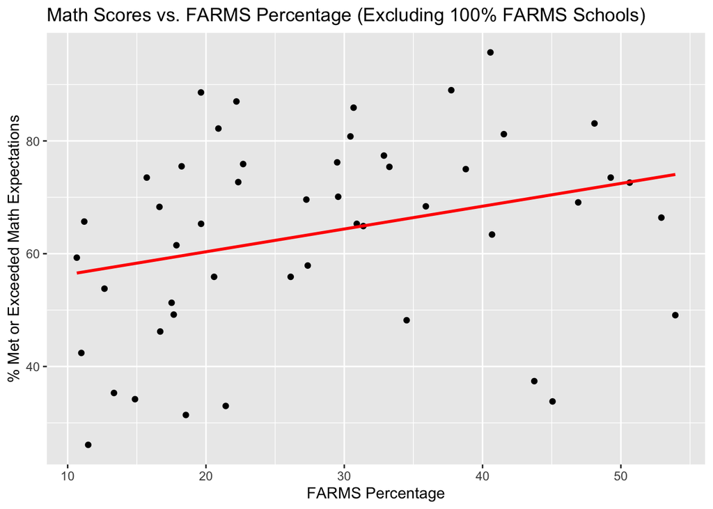

```r
schools_filtered |>
  ggplot(aes(x = `FARMS Pct`, y = `% Met or Exceeded Math Expectations`)) +
  geom_point() +
  geom_smooth(method = "lm", se = FALSE, color = "red") +
  labs(x = "FARMS Percentage", y = "% Met or Exceeded Math Expectations",
       title = "Math Scores vs. FARMS Percentage (Excluding 100% FARMS Schools)")
```

With a low R-squared, the residuals from this model aren’t very meaningful as labels of “over-performing” or “under-performing” — the model doesn’t know enough to make that judgment reliably. But let’s calculate them anyway to see the spread:

```r
schools_filtered <- schools_filtered |>
  mutate(
    predicted = predict(model_filtered),
    residual = `% Met or Exceeded Math Expectations` - predicted,
    abs_residual = abs(residual)
  ) |>
  arrange(desc(abs_residual))

head(schools_filtered |> select(1, `FARMS Pct`, `% Met or Exceeded Math Expectations`, predicted, residual), 10)
```

```
## # A tibble: 10 × 5
##    `School Name`         `FARMS Pct` % Met or Exceeded Math…¹ predicted residual
##    <chr>                       <dbl>                    <dbl>     <dbl>    <dbl>
##  1 GULPH ELEMENTARY SCH         45.1                     33.8      70.5    -36.7
##  2 HEREFORD EL SCH              43.7                     37.4      69.9    -32.5
##  3 WHITEMARSH EL SCH            11.5                     26.1      56.9    -30.8
##  4 WOODLAND EL SCH              19.6                     88.6      60.2     28.4
##  5 LOWER GWYNEDD EL SCH         18.5                     31.4      59.8    -28.4
##  6 RYDAL WEST SCH               21.4                     33        60.9    -27.9
##  7 CROOKED BILLET EL SCH        40.6                     95.7      68.7     27.0
##  8 RIDGE PARK EL SCH            22.2                     87        61.2     25.8
##  9 E M CROUTHAMEL EL SCH        53.9                     49.1      74.1    -25.0
## 10 BELMONT HILLS EL SCH         14.9                     34.2      58.3    -24.1
## # ℹ abbreviated name: ¹`% Met or Exceeded Math Expectations`
```

What are the largest residuals? Given the model’s weak R-squared, how much confidence would you have in labeling these schools as over- or under-performers? Why?

I wouldn’t have mich confidence because the points are still scattered all over the place the residuals show a big gap from the actuality of the situation.

### Task 6: Write the Story Pitch

You’ve now run two models, examined the data quality and seen that even a cleaned-up model explains very little of the variation in math scores. Return to the school board member’s claim: that schools with fewer students on free and reduced-price meals do better on standardized math tests.

Write a short story pitch (3-5 sentences) that addresses the following: Does the data support or contradict the claim? What data quality issues did you find? What would you need - different data, a different model, additional reporting - before you could responsibly publish a story about this claim? Who would you call first?

The data does not support the school board member’s claim. Even after removing suspicious schools with 100% FARMS rates, the relationship between poverty and math scores is weak and the direction of the relationship does not match.

The dataset also raises alarm bells about data quality= potentially misreported FARMS values that distort the model. Before I publish, I would need additional data: school funding/demographic breakdowns.

I would call the Montgomery County school district or state education officials to clarify how FARMS data is reported and whether those 100% values reflect real conditions.